# p8105_hw3_xs2529

2023-10-15

### Problem 1

#### Read in the data

```r
data("instacart")

instacart =
  instacart |>
  as_tibble()
```

#### Answer questions about the data

This dataset contains 1384617 rows and 15 columns, with each row resprenting a single product from an instacart order. Variables include identifiers for user, order, and product; the order in which each product was added to the cart. There are several order-level variables, describing the day and time of the order, and number of days since prior order. Then there are several item-specific variables, describing the product name (e.g. Yogurt, Avocado), department (e.g. dairy and eggs, produce), and aisle (e.g. yogurt, fresh fruits), and whether the item has been ordered by this user in the past. In total, there are 39123 products found in 131209 orders from 131209 distinct users.

Below is a table summarizing the number of items ordered from aisle. In total, there are 134 aisles, with fresh vegetables and fresh fruits holding the most items ordered by far.

```r
instacart |>
  count(aisle) |>
  arrange(desc(n))
```

```
## # A tibble: 134 × 2
##    aisle                              n
##    <chr>                          <int>
##  1 fresh vegetables              150609
##  2 fresh fruits                  150473
##  3 packaged vegetables fruits     78493
##  4 yogurt                         55240
##  5 packaged cheese                41699
##  6 water seltzer sparkling water  36617
##  7 milk                           32644
##  8 chips pretzels                 31269
##  9 soy lactosefree                26240
## 10 bread                          23635
## # ℹ 124 more rows
```

Next is a plot that shows the number of items ordered in each aisle. Here, aisles are ordered by ascending number of items.

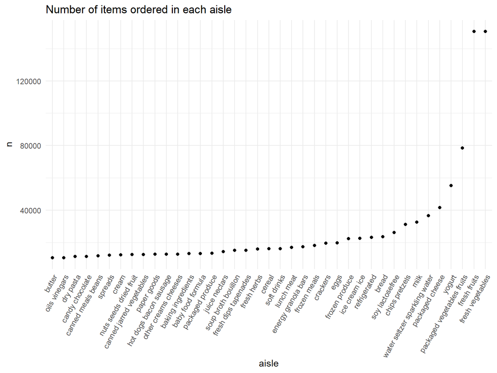

```r
instacart |>
  count(aisle) |>
  filter(n > 10000) |>
  mutate(aisle = fct_reorder(aisle, n)) |>
  ggplot(aes(x = aisle, y = n)) +
  geom_point() +
  labs(title = "Number of items ordered in each aisle") +
  theme(axis.text.x = element_text(angle = 60, hjust = 1))
```

Our next table shows the three most popular items in aisles `baking ingredients`, `dog food care`, and `packaged vegetables fruits`, and includes the number of times each item is ordered in your table.

```r
instacart |>
  filter(aisle %in% c("baking ingredients", "dog food care", "packaged vegetables fruits")) |>
  group_by(aisle) |>
  count(product_name) |>
  mutate(rank = min_rank(desc(n))) |>
  filter(rank < 4) |>
  arrange(desc(n)) |>
  knitr::kable()
```

| aisle | product_name | n | rank |
| --- | --- | --- | --- |
| packaged vegetables fruits | Organic Baby Spinach | 9784 | 1 |
| packaged vegetables fruits | Organic Raspberries | 5546 | 2 |
| packaged vegetables fruits | Organic Blueberries | 4966 | 3 |
| baking ingredients | Light Brown Sugar | 499 | 1 |
| baking ingredients | Pure Baking Soda | 387 | 2 |
| baking ingredients | Cane Sugar | 336 | 3 |
| dog food care | Snack Sticks Chicken & Rice Recipe Dog Treats | 30 | 1 |
| dog food care | Organix Chicken & Brown Rice Recipe | 28 | 2 |
| dog food care | Small Dog Biscuits | 26 | 3 |

Finally is a table showing the mean hour of the day at which Pink Lady Apples and Coffee Ice Cream are ordered on each day of the week. This table has been formatted in an untidy manner for human readers. Pink Lady Apples are generally purchased slightly earlier in the day than Coffee Ice Cream, with the exception of day 5.

```r
instacart |>
  filter(product_name %in% c("Pink Lady Apples", "Coffee Ice Cream")) |>
  group_by(product_name, order_dow) |>
  summarize(mean_hour = mean(order_hour_of_day)) |>
  pivot_wider(
    names_from = order_dow,
    values_from = mean_hour) |>
  knitr::kable(digits = 2)
```

| product_name | 0 | 1 | 2 | 3 | 4 | 5 | 6 |
| --- | --- | --- | --- | --- | --- | --- | --- |
| Coffee Ice Cream | 13.77 | 14.32 | 15.38 | 15.32 | 15.22 | 12.26 | 13.83 |
| Pink Lady Apples | 13.44 | 11.36 | 11.70 | 14.25 | 11.55 | 12.78 | 11.94 |

### Problem 2

#### Read in the data

```r
data("brfss_smart2010")

brfss_smart2010 =
  brfss_smart2010 |>
  as_tibble()
```

#### Data Cleaning

```r
brfss_smart2010 = brfss_smart2010 |>
  janitor::clean_names() |>
  filter(topic == "Overall Health" & response %in% c("Excellent", "Very good", "Good", "Fair", "Poor")) |>
  mutate(response = factor(response, levels = c("Poor", "Fair", "Good", "Very good", "Excellent"))) |> #change response to factor levels
  arrange(response) #arrange by response
```

#### States were observed at 7 or more locations in 2002 and 2010

```r
#States in 2002
states_2002 <- brfss_smart2010 |>
  filter(year == 2002) |>
  group_by(locationabbr) |>
  summarize(locationNum = n_distinct(locationdesc)) |>
  filter(locationNum >= 7) #filter out 7 or more locations

# States in 2010
states_2010 <- brfss_smart2010 |>
  filter(year == 2010) |>
  group_by(locationabbr) |>
  summarize(locationNum = n_distinct(locationdesc)) |>
  filter(locationNum >= 7)
```

In 2002, 7 or more locations were observed in CT, FL, MA, NC, NJ, PA.

In 2010, CA, CO, FL, MA, MD, NC, NE, NJ, NY, OH, PA, SC, TX, WA observed 7 or more locations.

#### Make a “spaghetti” plot of this average value over time within a state

```r
excellent_data <- brfss_smart2010 |>
  filter(response == "Excellent") |>
  group_by(year, locationabbr) |>
  summarize(avg_value = mean(data_value))
```

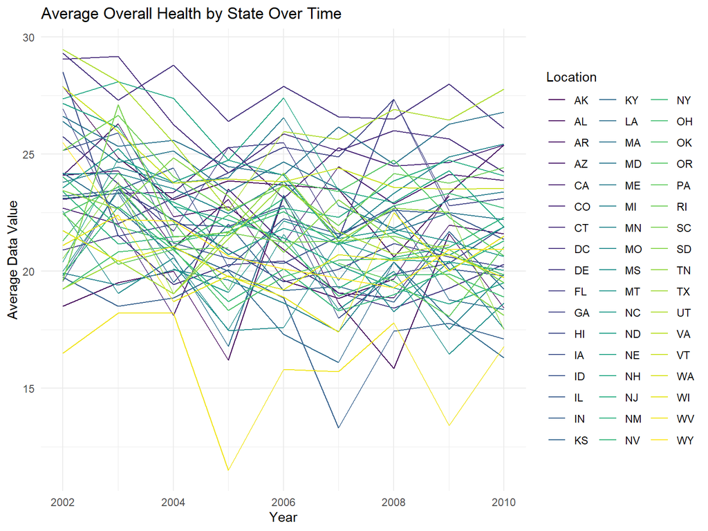

```r
ggplot(excellent_data, aes(x = year, y = avg_value, group = locationabbr, color = locationabbr)) +
  geom_line() +
  labs(title = "Average Overall Health by State Over Time",
       x = "Year",
       y = "Average Data Value",
      color = "Location" ) +
  theme(legend.position = "right")
```

This figure shows the average `data_value` with the `excellent` response within state across time. It shows the average values are fluctuating between years for each state.

#### Distribution of data_value for responses (“Poor” to “Excellent”) among locations in NY State in 2006 and 2010

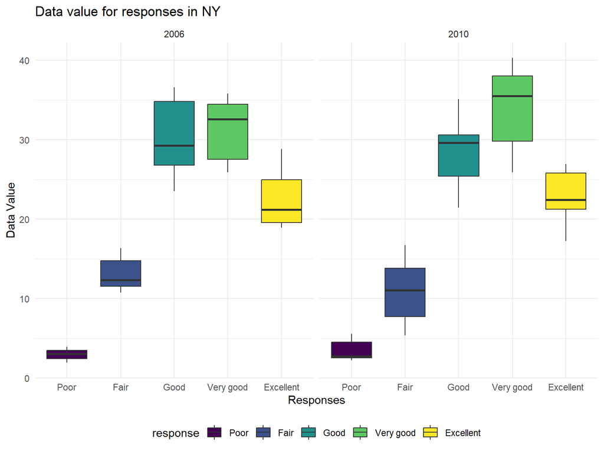

```r
ny_data <- brfss_smart2010 |>
  filter(locationabbr == "NY" & year %in% c(2006, 2010))

ggplot(ny_data, aes(x= response, y = data_value, fill = response))+
  geom_boxplot()+
  labs(title="Data value for responses in NY", x="Responses", y="Data Value") +
  facet_wrap(~year)
```

This figure displays the `data value` categorized by responses for the years 2006 and 2010. The distributions in 2006 and 2010 are highly alike. Overall, the highest `data value` were achieved for responses `Good` and `Very Good` in both 2006 and 2010. Conversely, the lowest `data value` are associated with the `Poor` response.

#### Problem 3

```r
demographic_data <- read_csv("data/nhanes_covar.csv", skip = 4)
accelerometer_data <- read_csv("data/nhanes_accel.csv")
demographic_clean = demographic_data |>
  janitor::clean_names() |>
  drop_na() |>
  filter(age >= 21) |>
  mutate (sex = ifelse(sex == 1, "Male", "Female")) |> #change sex to meaningful values
  mutate (education = factor(education, levels = 1:3, labels = c("Less than high school", "High school equivalent", "More than high school"), ordered = TRUE)) |> #change education to factor levels
  mutate(sex = factor(sex),
         education = factor(education))

accelerometer_clean = accelerometer_data |>
  rename("seqn" = "SEQN") #rename for merge

accelerometer_pivot = accelerometer_clean |>
  pivot_longer(
    min1:min1440,
    names_to = "min_number",
    values_to = "mims_values") #perform pivot for analysis

mims_merge =
  left_join(demographic_clean, accelerometer_clean, by = "seqn")

mims_pivot =
  left_join(demographic_clean, accelerometer_pivot, by = "seqn")
```

#### Table of men and women in each education category

```r
table_education_sex = mims_merge |>
  group_by(education, sex) |>
  summarize(count = n()) |>
  pivot_wider(names_from = sex, values_from = count)
print(table_education_sex)
```

```
## # A tibble: 3 × 3
## # Groups:   education [3]
##   education              Female  Male
##   <ord>                   <int> <int>
## 1 Less than high school      28    27
## 2 High school equivalent     23    35
## 3 More than high school      59    56
```

Both male and female have the highest amount of people who get `more than high school education`.

#### Visualization of age distributions

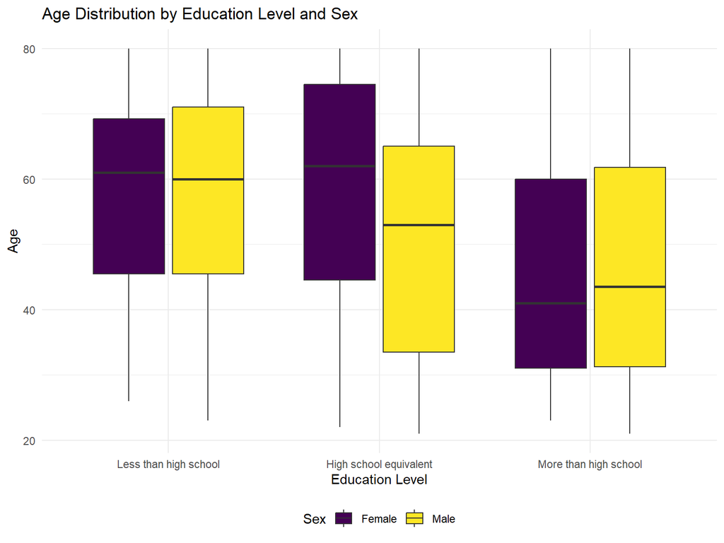

```r
ggplot(mims_merge, aes(x = education, y = age, fill = sex)) +
  geom_boxplot() +
  labs(title = "Age Distribution by Education Level and Sex",
       x = "Education Level",
       y = "Age",
       fill = "Sex")
```

This figure shows the distribution of men and women in each eduation category.

The median age for participants with an education level `Less Than High School` is around 60 for men, and around 61 for women.

The median age for participants with an education level `High school equivalent` is around 50 for men, and around 62 for women.

The median age for participants with an education level `More than high school` is around 43 for men, and 41 for women.

```r
total_mims = mims_pivot |>
  group_by(seqn, age, sex, education) |>
  summarise(total_activity = sum(mims_values) )
```

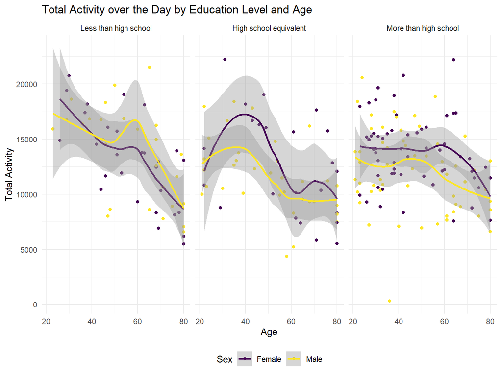

```r
ggplot(total_mims, aes(x = age, y = total_activity, color = sex)) +
  geom_point() +
  geom_smooth() +
  facet_wrap(~ education) +
  labs(title = "Total Activity over the Day by Education Level and Age",
       x = "Age",
       y = "Total Activity",
       color = "Sex"
       )
```

This figure shows the total activity over the day by education level and age. Overall, there’s a decreasing trend of total daily activity across age. However, the dereasing is less significant as the education level increases. The differences between sex is not significant.

```r
daily_activity = mims_pivot |>
  mutate(across(starts_with("min"), ~ as.numeric(str_extract(., "\\d+")))) |>
  group_by(min_number, sex, education) |>
  arrange(min_number) |>
  summarise(avg_activity = mean(mims_values))
```

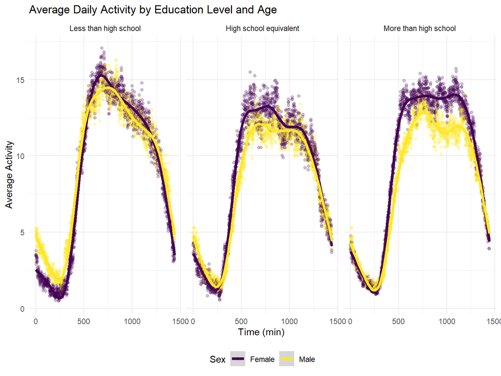

```r
ggplot(daily_activity, aes(x = min_number, y = avg_activity, color = sex)) +
  geom_point(alpha = 0.25) +
  geom_smooth(linetype = "solid", size = 1.5) +
  facet_wrap( ~ education) +
  labs(title = "Average Daily Activity by Education Level and Age",
       x = "Time (min) ",
       y = "Average Activity",
       color = "Sex"
       )
```

This figure shows the average daily activity by education level and age. Overall, the average activity decreases at the begining, then suddenly increases till the noon, and then droppped back. There’s no significant differences across education level. The population with `Less than high school` education level shows highest peak performance, and the population with `High School Equivalent` education level shows the lowest peak performance. Generally, female exhibit higher average daily activity compared to male.